# AllLife_Bank_Unsupervised_Learning

**Objective:**

- To identify different segments in the existing customer based on their spending patterns as well as past interaction with the bank.
- To run customer targetted advertisement and aswell upselling the existing customer.
- Upgrade the service delivery Model.

**Back Ground:** Data collected has customers credit limit, number of credit cards, customer contact through visiting bank, online banking and through call center.

**Dataset:** ALLLife bank

**Data Description:** Data is of various customers of a bank with their credit limit, the total number of credit cards the customer has, and different channels through which customer has contacted the bank for any queries, different channels include visiting the bank, online and through a call centre.

**Task:**

1. Perform EDA
2. Apply Clustering Mechanism.
3. Compare different clustering mechanism
4. Provide Insights to the bank.

**Order of Notebook**

1. Content analysis.
2. Finding Duplicate and outlier treatment.
3. Exploratory Dataa Analysis - Relationship between features.
4. Univariate Analysis - Plotting
5. Bivariate Analysis - Plotting.
6. KMeans Clustering - Elbow and Silhoutte score.
7. Heirarchy Clustering - Dendograms with linkages.
8. Profiling comparison of kmeans and Heirarchy clustering
9. Final Recommendation

**Import Library Files**

```python
# Pandas and Numpy to handle dataframe and working on numbers.
import pandas as pd
import numpy as np

# Matplotlib for plotting
import matplotlib.pyplot as plt
%matplotlib inline
import warnings

# seaborn for plotting
import seaborn as sns

# Zscore
from scipy.stats import zscore

# Displaying Full width in notebook.
from IPython.core.display import display, HTML
display(HTML("<style>.container { width:100% !important; }</style>"))

# Scipy Module for distance calucualtion and hierarchy Clusters
from scipy.spatial.distance import cdist
from scipy.spatial.distance import pdist
from scipy.cluster.hierarchy import dendrogram, linkage,cophenet
from scipy.cluster.hierarchy import fcluster

# SKlearn Module for KMeans Agglomerative Clustering
from sklearn.cluster import AgglomerativeClustering
from sklearn.cluster import KMeans
from sklearn.preprocessing import StandardScaler
from sklearn.metrics import silhouette_score
from sklearn.decomposition import PCA # importing PCA will use if needed


#Silhouette Visualizer
from yellowbrick.cluster import KElbowVisualizer, SilhouetteVisualizer
```

```python
from google.colab import drive
drive.mount('/content/drive')
```

```python
creditCardCustomerDF= pd.read_excel('/content/drive/MyDrive/Credit Card Customer Data.xlsx','Sheet1')
```

```python
creditCardCustomerDF.shape
```

```
(660, 7)
```

```python
creditCardCustomerDF.head()
```

|  | Sl_No | Customer Key | Avg_Credit_Limit | Total_Credit_Cards | Total_visits_bank | Total_visits_online | Total_calls_made |
| --- | --- | --- | --- | --- | --- | --- | --- |
| 0 | 1 | 87073 | 100000 | 2 | 1 | 1 | 0 |
| 1 | 2 | 38414 | 50000 | 3 | 0 | 10 | 9 |
| 2 | 3 | 17341 | 50000 | 7 | 1 | 3 | 4 |
| 3 | 4 | 40496 | 30000 | 5 | 1 | 1 | 4 |
| 4 | 5 | 47437 | 100000 | 6 | 0 | 12 | 3 |

```python
creditCardCustomerDF.describe().T
```

|  | count | mean | std | min | 25% | 50% | 75% | max |
| --- | --- | --- | --- | --- | --- | --- | --- | --- |
| Sl_No | 660.0 | 330.500000 | 190.669872 | 1.0 | 165.75 | 330.5 | 495.25 | 660.0 |
| Customer Key | 660.0 | 55141.443939 | 25627.772200 | 11265.0 | 33825.25 | 53874.5 | 77202.50 | 99843.0 |
| Avg_Credit_Limit | 660.0 | 34574.242424 | 37625.487804 | 3000.0 | 10000.00 | 18000.0 | 48000.00 | 200000.0 |
| Total_Credit_Cards | 660.0 | 4.706061 | 2.167835 | 1.0 | 3.00 | 5.0 | 6.00 | 10.0 |
| Total_visits_bank | 660.0 | 2.403030 | 1.631813 | 0.0 | 1.00 | 2.0 | 4.00 | 5.0 |
| Total_visits_online | 660.0 | 2.606061 | 2.935724 | 0.0 | 1.00 | 2.0 | 4.00 | 15.0 |
| Total_calls_made | 660.0 | 3.583333 | 2.865317 | 0.0 | 1.00 | 3.0 | 5.00 | 10.0 |

```python
creditCardCustomerDF.info()
```

```
<class 'pandas.core.frame.DataFrame'>
RangeIndex: 660 entries, 0 to 659
Data columns (total 7 columns):
 #   Column               Non-Null Count  Dtype
---  ------               --------------  -----
 0   Sl_No                660 non-null    int64
 1   Customer Key         660 non-null    int64
 2   Avg_Credit_Limit     660 non-null    int64
 3   Total_Credit_Cards   660 non-null    int64
 4   Total_visits_bank    660 non-null    int64
 5   Total_visits_online  660 non-null    int64
 6   Total_calls_made     660 non-null    int64
dtypes: int64(7)
memory usage: 36.2 KB
```

**Insights of Data**

**Finding Duplicate and Outlier Treatment on Data Frame**

```python
creditCardCustomerDF['Customer Key'].nunique()
```

```
655
```

```python
creditCardCustomerDF[creditCardCustomerDF.duplicated()]
```

|  | Sl_No | Customer Key | Avg_Credit_Limit | Total_Credit_Cards | Total_visits_bank | Total_visits_online | Total_calls_made |
| --- | --- | --- | --- | --- | --- | --- | --- |

```python
creditCardCustomerDF[creditCardCustomerDF.duplicated('Customer Key')]['Customer Key']
```

```
332    47437
398    96929
432    37252
541    50706
632    97935
Name: Customer Key, dtype: int64
```

```python
creditCardCustomerDF[creditCardCustomerDF['Customer Key'] == 96929]
```

|  | Sl_No | Customer Key | Avg_Credit_Limit | Total_Credit_Cards | Total_visits_bank | Total_visits_online | Total_calls_made |
| --- | --- | --- | --- | --- | --- | --- | --- |
| 391 | 392 | 96929 | 13000 | 4 | 5 | 0 | 0 |
| 398 | 399 | 96929 | 67000 | 6 | 2 | 2 | 2 |

```python
creditCardCustomerDF = creditCardCustomerDF.drop_duplicates(subset=['Customer Key'],keep='last')
```

```python
creditCardCustomerDF.shape
```

```
(655, 7)
```

```python
creditCardCustomerDF[creditCardCustomerDF['Avg_Credit_Limit'] >= 190000]
```

|  | Sl_No | Customer Key | Avg_Credit_Limit | Total_Credit_Cards | Total_visits_bank | Total_visits_online | Total_calls_made |
| --- | --- | --- | --- | --- | --- | --- | --- |
| 630 | 631 | 33837 | 200000 | 10 | 0 | 13 | 0 |
| 631 | 632 | 14916 | 195000 | 8 | 0 | 15 | 0 |
| 650 | 651 | 78996 | 195000 | 10 | 1 | 12 | 2 |

```python
creditCardCustomerDF[creditCardCustomerDF['Total_visits_online'] >12]
```

|  | Sl_No | Customer Key | Avg_Credit_Limit | Total_Credit_Cards | Total_visits_bank | Total_visits_online | Total_calls_made |
| --- | --- | --- | --- | --- | --- | --- | --- |
| 612 | 613 | 94391 | 157000 | 9 | 1 | 14 | 1 |
| 617 | 618 | 98216 | 136000 | 8 | 0 | 13 | 0 |
| 618 | 619 | 54495 | 121000 | 7 | 0 | 13 | 2 |
| 619 | 620 | 47650 | 158000 | 7 | 0 | 13 | 0 |
| 620 | 621 | 32107 | 108000 | 10 | 0 | 15 | 1 |
| 622 | 623 | 53916 | 176000 | 10 | 1 | 15 | 2 |
| 628 | 629 | 75009 | 84000 | 9 | 1 | 15 | 0 |
| 630 | 631 | 33837 | 200000 | 10 | 0 | 13 | 0 |
| 631 | 632 | 14916 | 195000 | 8 | 0 | 15 | 0 |
| 639 | 640 | 90839 | 184000 | 7 | 1 | 15 | 2 |
| 640 | 641 | 99843 | 123000 | 8 | 1 | 15 | 2 |
| 644 | 645 | 18519 | 127000 | 10 | 1 | 15 | 1 |
| 645 | 646 | 48762 | 171000 | 10 | 0 | 15 | 0 |
| 653 | 654 | 51826 | 95000 | 10 | 0 | 15 | 1 |
| 656 | 657 | 60732 | 84000 | 10 | 1 | 13 | 2 |
| 658 | 659 | 80655 | 172000 | 10 | 1 | 15 | 0 |

**Insights of Duplicate**

1. Total Observation is 660 Rows.
2. Customer Key has unique value of 655.
3. There are 5 rows of duplicate
4. Treating the duplicates in customer key to keep last.

**On Outlier Treatment**

**Dropping Sl_No and Customer Key for proceeding analysis**

```python
 ccCustomerDF = creditCardCustomerDF.drop(['Sl_No', 'Customer Key'],axis=1)
```

**Exploratory Data Analysis Relationship and Indvidual**

```python
ccCustomerDF.columns
```

```
Index(['Avg_Credit_Limit', 'Total_Credit_Cards', 'Total_visits_bank',
       'Total_visits_online', 'Total_calls_made'],
      dtype='object')
```

```python
def custom_round(x, base=30):
    return int(base * round(float(x)/base))
ccCustomerDF['Avg_Credit_Limit_Category'] = ccCustomerDF['Avg_Credit_Limit'].apply(lambda x: custom_round(x, base=20000))

print("Avg_Credit_Limit  - Number of calls made turnover")
G1 = ccCustomerDF.groupby(['Avg_Credit_Limit_Category','Total_calls_made'])['Total_calls_made'].count()
print('+'*30)
print('By count')
print('+'*30)
print(G1)
print('+'*30)
print('By percentage')
print('+'*30)
print(G1.groupby(level=0).apply(lambda x: 100 * x / float(x.sum())))
print('+'*30)
ccCustomerDF['Avg_Credit_Limit_Category'] = pd.Categorical(ccCustomerDF['Avg_Credit_Limit_Category'])
```

```
Avg_Credit_Limit  - Number of calls made turnover
++++++++++++++++++++++++++++++
By count
++++++++++++++++++++++++++++++
Avg_Credit_Limit_Category  Total_calls_made
0                          0                   14
                           1                   14
                           2                    9
                           3                   17
                           4                   30
                           5                   14
                           6                   16
                           7                   15
                           8                   12
                           9                   10
```

[output cut: 107 more lines]

**Insights of Avg Credit card Limit Vs Number of call Made**

1. Below 40000 credit limit - number of calls made by customer looks more.
2. As credit limit increases number of calls made by customer decreases.

```python
print("Avg_Credit_Limit  - Total_visits_bank turnover")
ccCustomerDF['Avg_Credit_Limit_Category'] = ccCustomerDF['Avg_Credit_Limit'].apply(lambda x: custom_round(x, base=50000))
G1 = ccCustomerDF.groupby(['Avg_Credit_Limit_Category','Total_visits_bank'])['Total_visits_bank'].count()
print('+'*30)
print('By count')
print('+'*30)
print(G1)
print('+'*30)
print('By percentage')
print('+'*30)
print(G1.groupby(level=0).apply(lambda x: 100 * x / float(x.sum())))
print('+'*30)
```

```
Avg_Credit_Limit  - Total_visits_bank turnover
++++++++++++++++++++++++++++++
By count
++++++++++++++++++++++++++++++
Avg_Credit_Limit_Category  Total_visits_bank
0                          0                     78
                           1                     78
                           2                    104
                           3                     39
                           4                     40
                           5                     49
50000                      0                      1
                           1                      2
                           2                     54
                           3                     60
```

[output cut: 37 more lines]

**Avg_Credit_Limit - Total_visits_bank**

1. Number of visit to bank is decreases when credit limit is increases.

```python
# Total_visits_online

print("Avg_Credit_Limit  - Total_visits_online turnover")
ccCustomerDF['Avg_Credit_Limit_Category'] = ccCustomerDF['Avg_Credit_Limit'].apply(lambda x: custom_round(x, base=50000))
G1 = ccCustomerDF.groupby(['Avg_Credit_Limit_Category','Total_visits_online'])['Total_visits_online'].count()
print('+'*30)
print('By count')
print('+'*30)
print(G1)
print('+'*30)
print('By percentage')
print('+'*30)
print(G1.groupby(level=0).apply(lambda x: 100 * x / float(x.sum())))
print('+'*30)
```

```
Avg_Credit_Limit  - Total_visits_online turnover
++++++++++++++++++++++++++++++
By count
++++++++++++++++++++++++++++++
Avg_Credit_Limit_Category  Total_visits_online
0                          0                       62
                           1                       46
                           2                      114
                           3                       43
                           4                       69
                           5                       54
50000                      0                       79
                           1                       62
                           2                       72
                           3                        1
```

[output cut: 73 more lines]

**Avg_Credit_Limit - Total_visits_online**

1. when credit limit increases number of online visit increases.

```python
print("total credit card count  - Total_visits_online turnover")
# ccCustomerDF['Avg_Credit_Limit_Category'] = ccCustomerDF['Avg_Credit_Limit'].apply(lambda x: custom_round(x, base=50000))
G1 = ccCustomerDF.groupby(['Total_Credit_Cards','Total_visits_online'])['Total_visits_online'].count()
print('+'*30)
print('By count')
print('+'*30)
print(G1)
print('+'*30)
print('By percentage')
print('+'*30)
print(G1.groupby(level=0).apply(lambda x: 100 * x / float(x.sum())))
print('+'*30)
```

```
total credit card count  - Total_visits_online turnover
++++++++++++++++++++++++++++++
By count
++++++++++++++++++++++++++++++
Total_Credit_Cards  Total_visits_online
1                   2                      18
                    3                       9
                    4                      17
                    5                      15
2                   1                       1
                    2                      13
                    3                      15
                    4                      18
                    5                      16
3                   1                       2
```

[output cut: 115 more lines]

**total credit card count - Total_visits_online**

1. When number of credit card increase, the total online visit increases.

```python
print("total credit card count  - Total_calls_made turnover")
# ccCustomerDF['Avg_Credit_Limit_Category'] = ccCustomerDF['Avg_Credit_Limit'].apply(lambda x: custom_round(x, base=50000))
G1 = ccCustomerDF.groupby(['Total_Credit_Cards','Total_calls_made'])['Total_calls_made'].count()
print('+'*30)
print('By count')
print('+'*30)
print(G1)
print('+'*30)
print('By percentage')
print('+'*30)
print(G1.groupby(level=0).apply(lambda x: 100 * x / float(x.sum())))
print('+'*30)
```

```
total credit card count  - Total_calls_made turnover
++++++++++++++++++++++++++++++
By count
++++++++++++++++++++++++++++++
Total_Credit_Cards  Total_calls_made
1                   4                    6
                    5                    8
                    6                    7
                    7                   12
                    8                    7
                    9                   10
                    10                   9
2                   0                    1
                    2                    1
                    4                   12
```

[output cut: 115 more lines]

**Total credit card count - Total_calls_made**

1. When credti card count increases number of call made decreases.

```python
ccCustomerDF.columns
```

```
Index(['Avg_Credit_Limit', 'Total_Credit_Cards', 'Total_visits_bank',
       'Total_visits_online', 'Total_calls_made', 'Avg_Credit_Limit_Category'],
      dtype='object')
```

```python
ccCustomerDF.drop(columns=['Avg_Credit_Limit_Category'],inplace=True)
```

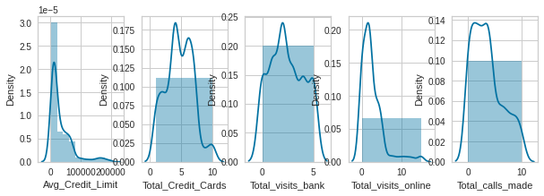

```python
#Let us use seaborn distplot to analyze the distribution of our columns
f, ax = plt.subplots(1, 5, figsize=(10,3))
vis1 = sns.distplot(ccCustomerDF["Avg_Credit_Limit"],bins=10, ax= ax[0])
vis2 = sns.distplot(ccCustomerDF["Total_Credit_Cards"],bins=1, ax=ax[1])
vis3 = sns.distplot(ccCustomerDF["Total_visits_bank"],bins=1, ax= ax[2])
vis4 = sns.distplot(ccCustomerDF["Total_visits_online"],bins=1, ax=ax[3])
vis5 = sns.distplot(ccCustomerDF["Total_calls_made"],bins=1, ax=ax[4])
# f.savefig('subplot.png')
```

```python
# sns.pairplot(ccCustomerDF, diag_kind="kde")
```

```python
# sns.pairplot( ccCustomerDF,diag_kind="kde", markers=["o", "s", "D"])
```

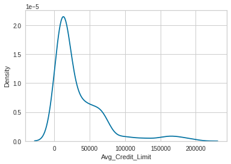

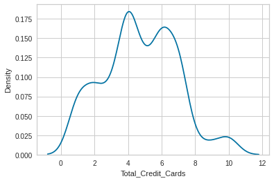

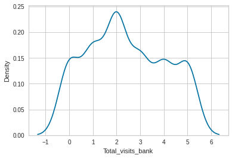

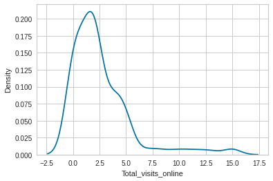

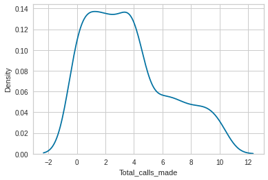

```python
for i in ccCustomerDF.columns[ccCustomerDF.columns!='class']:
    sns.distplot(ccCustomerDF[i],hist=False,)
    plt.show()
```

**Insights**

1. Number of peaks in the univariate graph shows around 3 to 6.
2. Total visits online is skewed towards right.
3. Total Bank visit, Total Credit card are close to the normal distribution.

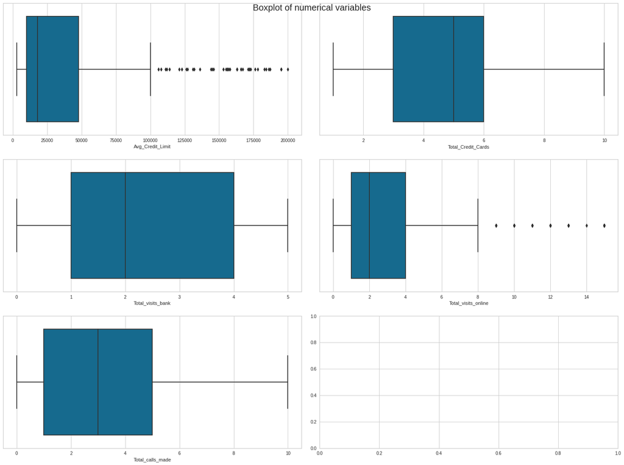

```python
# selecting numerical columns
all_col = ccCustomerDF.select_dtypes(include=np.number).columns.tolist()

fig, axes = plt.subplots(3, 2,  figsize=(20, 15))
fig.suptitle('Boxplot of numerical variables', fontsize=20)
counter = 0
for ii in range(3):
    sns.boxplot(ax=axes[ii][0],x=ccCustomerDF[all_col[counter]])
    counter = counter+1
    if counter != 5:
        sns.boxplot(ax=axes[ii][1],x=ccCustomerDF[all_col[counter]])
        counter = counter+1
    else:
        pass

fig.tight_layout(pad=2.0)
```

**Insights**

1. There is outlier in Average Credit Limit, Total visits online
2. Majority Credit cards count in average of 3 to 6.
3. Total visit to banks is in majority range 1 to 4

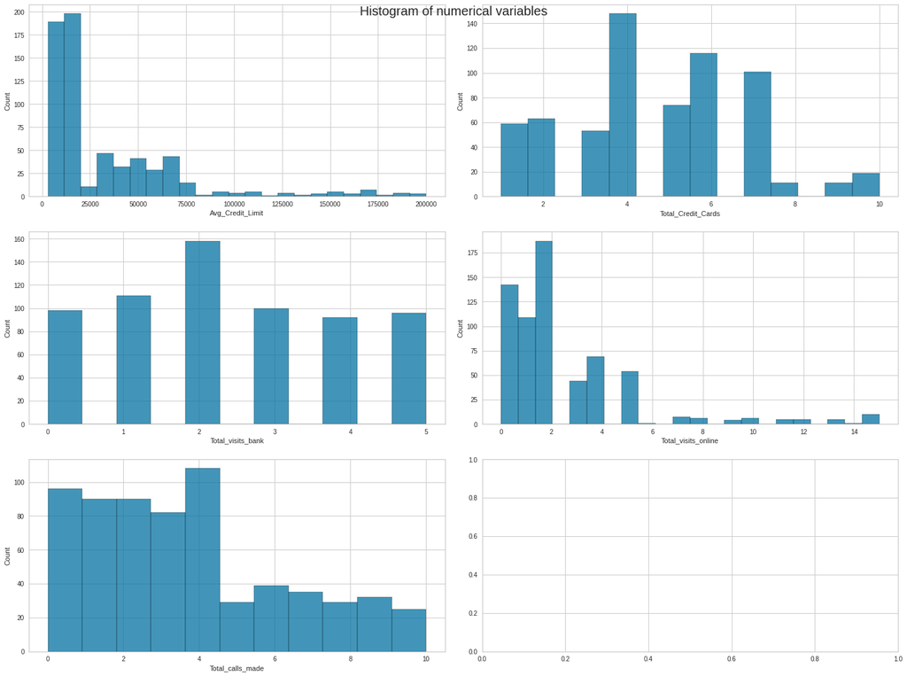

```python
# select numerical columns
all_col = ccCustomerDF.select_dtypes(include=np.number).columns.tolist()

fig, axes = plt.subplots(3, 2,  figsize=(20, 15))
fig.suptitle('Histogram of numerical variables', fontsize=20)
counter = 0
for ii in range(3):
    sns.histplot(ax=axes[ii][0],x=ccCustomerDF[all_col[counter]])
    counter = counter+1
    if counter != 5:
        sns.histplot(ax=axes[ii][1],x=ccCustomerDF[all_col[counter]])
        counter = counter+1
    else:
        pass

fig.tight_layout(pad=2.0)
```

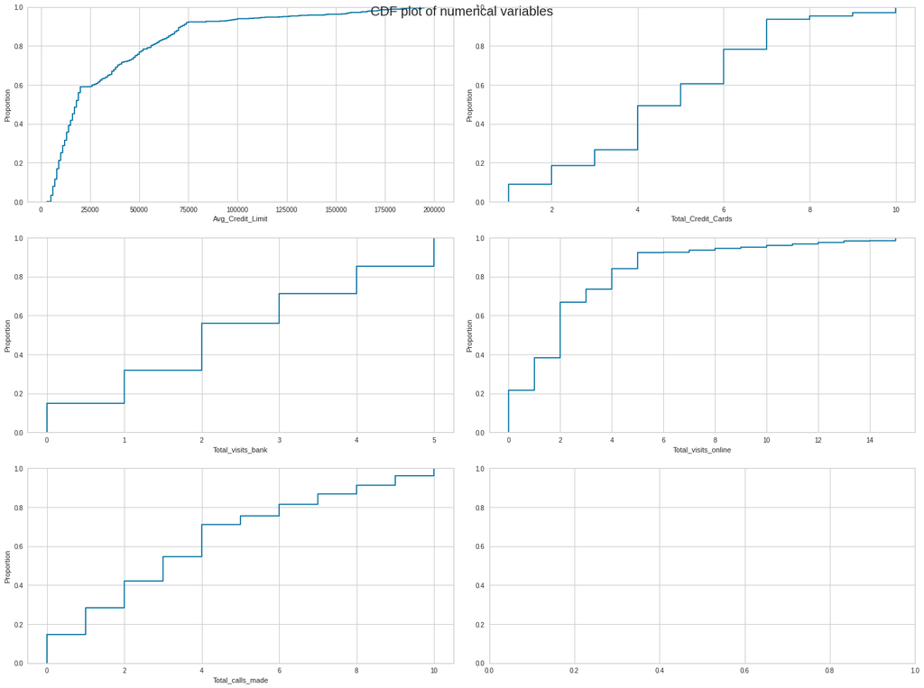

```python
# select numerical columns
all_col = ccCustomerDF.select_dtypes(include=np.number).columns.tolist()

fig, axes = plt.subplots(3, 2,  figsize=(20, 15))
fig.suptitle('CDF plot of numerical variables', fontsize=20)
counter = 0
for ii in range(3):
    sns.ecdfplot(ax=axes[ii][0],x=ccCustomerDF[all_col[counter]])
    counter = counter+1
    if counter != 5:
        sns.ecdfplot(ax=axes[ii][1],x=ccCustomerDF[all_col[counter]])
        counter = counter+1
    else:
        pass


fig.tight_layout(pad=2.0)
```

**Insights of Univariate Analysis**

1. customer with 4 number of creditcard are dominant group.
2. There are skewness in the total numbers of all made.
3. Average credit card limit under 25000 is majority.

**Bivariate Analysis**

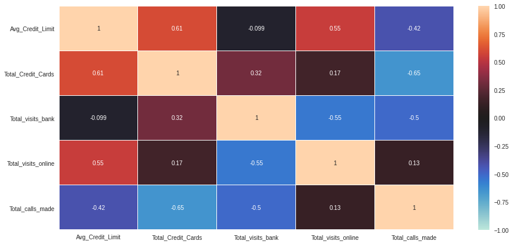

```python
plt.figure(figsize=(15,7))

sns.heatmap(ccCustomerDF[all_col].corr(),
            annot=True,
            linewidths=0.5,vmin=-1,vmax=1,
            center=0,
            cbar=True,)

plt.show()
```

**Insights of Heat Map**

1. Avg Credit limit corelated to total credit cards.
2. Total Credit cards positively correlaed to the banks visit at 0.32.
3. Avg credit limit is negatively correlated with the calls made but positively corelated with online visit.

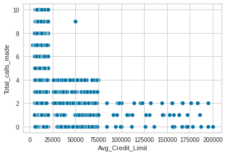

```python
sns.scatterplot(x=ccCustomerDF.Avg_Credit_Limit,y=ccCustomerDF.Total_calls_made)
```

**Avg Credit Limit vs total_calls_made**

1. Total call mage above credit limit is relatively low.
2. Graph is skewed to the right.
3. Most customers under 75000 forms dominant group

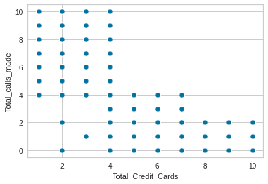

```python
sns.scatterplot(x=ccCustomerDF.Total_Credit_Cards,y=ccCustomerDF.Total_calls_made)
```

**Total Credit Cards Vs Total Calls Made**

1. When ttoal number of credit cards increases, the number of call made decreases.

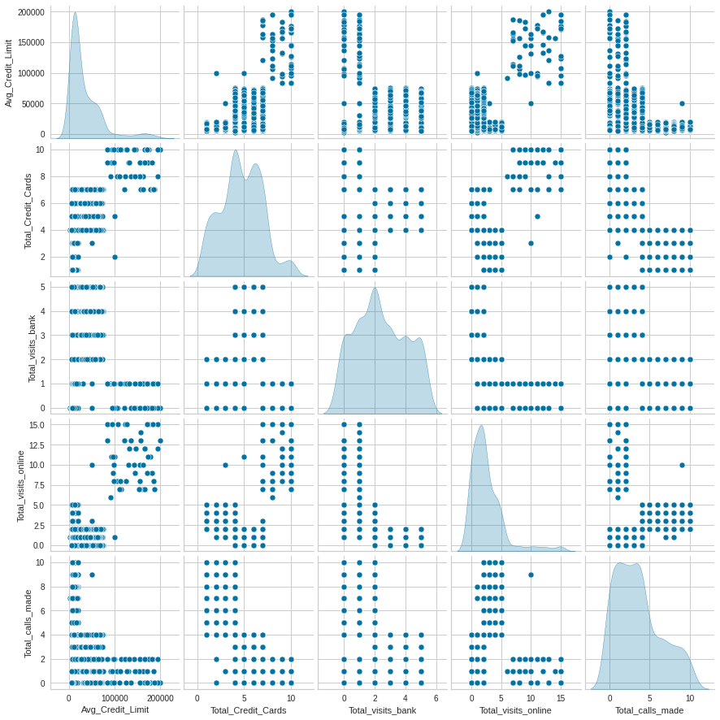

```python
sns.pairplot(ccCustomerDF, diag_kind="kde")
```

**Pair Plot Insights**

1. As we observer pair plot , number of peaks in range of 3 to 6.
2. Total Visit bank with total credit card remain in constant range of 0 to 1.
3. When total credit cards increses the number of online visit increases.

```python
all_col = ccCustomerDF.columns
all_col
```

```
Index(['Avg_Credit_Limit', 'Total_Credit_Cards', 'Total_visits_bank',
       'Total_visits_online', 'Total_calls_made'],
      dtype='object')
```

**KMEAN Clustering**

*applying scaler to the data set for Kmeans*

```python
# Scaling the dataset before clustering
scaler=StandardScaler()
subset=ccCustomerDF[all_col].copy()
subset_scaled=scaler.fit_transform(subset)
```

```python
# Creating a dataframe of the above results
subset_scaled_df=pd.DataFrame(subset_scaled,columns=subset.columns)
```

```
Number of Clusters: 1 	Average Distortion: 2.005608636921872
Number of Clusters: 2 	Average Distortion: 1.455402402901143
Number of Clusters: 3 	Average Distortion: 1.146702589132039
Number of Clusters: 4 	Average Distortion: 1.0461484732614619
Number of Clusters: 5 	Average Distortion: 0.9907114149144921
Number of Clusters: 6 	Average Distortion: 0.9427360150585338
Number of Clusters: 7 	Average Distortion: 0.9091221414071969
Number of Clusters: 8 	Average Distortion: 0.8882880172755971
```

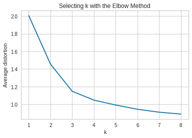

```python
clusters=range(1,9)
meanDistortions=[]

for k in clusters:
    model=KMeans(n_clusters=k)
    model.fit(subset_scaled_df)
    prediction=model.predict(subset_scaled_df)
    distortion=sum(np.min(cdist(subset_scaled_df, model.cluster_centers_, 'euclidean'), axis=1)) / subset_scaled_df.shape[0]

    meanDistortions.append(distortion)

    print('Number of Clusters:', k, '\tAverage Distortion:', distortion)

plt.plot(clusters, meanDistortions, 'bx-')
plt.xlabel('k')
plt.ylabel('Average distortion')
plt.title('Selecting k with the Elbow Method')
```

*From above Elbow curve we have below observation*

**Appropriate K Seems to be 3 to 4**

**SilhouetteVisualizer**

```
For n_clusters = 2, silhouette score is 0.4191048769542048)
For n_clusters = 3, silhouette score is 0.5156757893111308)
For n_clusters = 4, silhouette score is 0.35543523967554014)
For n_clusters = 5, silhouette score is 0.2714987436128599)
For n_clusters = 6, silhouette score is 0.255040032500671)
For n_clusters = 7, silhouette score is 0.24782449142527005)
For n_clusters = 8, silhouette score is 0.22449420496591982)
For n_clusters = 9, silhouette score is 0.22436075307559555)
```

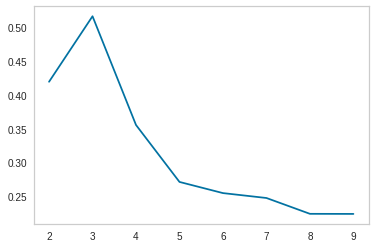

```python
sil_score = []
cluster_list = list(range(2,10))
for n_clusters in cluster_list:
    clusterer = KMeans(n_clusters=n_clusters)
    preds = clusterer.fit_predict((subset_scaled_df))
    #centers = clusterer.cluster_centers_
    score = silhouette_score(subset_scaled_df, preds)
    sil_score.append(score)
    print("For n_clusters = {}, silhouette score is {})".format(n_clusters, score))

plt.plot(cluster_list,sil_score)
plt.grid()
```

```
SilhouetteVisualizer(ax=<matplotlib.axes._subplots.AxesSubplot object at 0x7f9552cc2090>,
                     model=None)
```

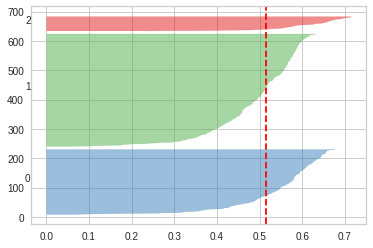

```python
# Finding optimal no. of clusters with silhouette coefficients
visualizer = SilhouetteVisualizer(KMeans(3, random_state = 1))
visualizer.fit(subset_scaled_df)
```

```
SilhouetteVisualizer(ax=<matplotlib.axes._subplots.AxesSubplot object at 0x7f955e316d90>,
                     model=None)
```

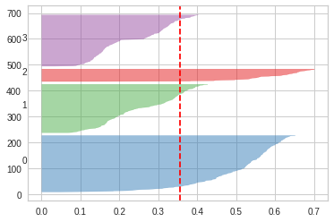

```python
# Finding optimal no. of clusters with silhouette coefficients
visualizer = SilhouetteVisualizer(KMeans(4, random_state = 1))
visualizer.fit(subset_scaled_df)
```

**Observation of SilhouetteVisualizer**

```python
# lets us take 4 as number of clusters
kmeans = KMeans(n_clusters=4, random_state=0)
kmeans.fit(subset_scaled_df)
```

```
KMeans(algorithm='auto', copy_x=True, init='k-means++', max_iter=300,
       n_clusters=4, n_init=10, n_jobs=None, precompute_distances='auto',
       random_state=0, tol=0.0001, verbose=0)
```

```python
ccCustomerDF['K_means_segments'] = kmeans.labels_
subset_scaled_df['K_means_segments'] = kmeans.labels_
```

```python
kmeans.labels_
```

```
array([0, 1, 0, 0, 1, 2, 0, 1, 1, 1, 1, 1, 1, 1, 1, 1, 1, 1, 1, 1, 1, 1,
       1, 1, 1, 1, 1, 1, 1, 1, 1, 1, 1, 1, 1, 1, 1, 1, 1, 1, 1, 0, 1, 1,
       1, 1, 1, 1, 1, 1, 1, 1, 1, 1, 1, 1, 1, 1, 1, 1, 1, 1, 1, 1, 1, 1,
       1, 1, 1, 1, 1, 1, 1, 1, 1, 1, 1, 1, 1, 1, 1, 1, 1, 1, 1, 1, 1, 1,
       1, 1, 1, 1, 1, 1, 1, 1, 1, 1, 1, 1, 1, 1, 1, 1, 1, 1, 1, 1, 1, 1,
       1, 1, 1, 1, 1, 1, 1, 1, 1, 1, 1, 1, 1, 1, 1, 1, 1, 1, 1, 1, 1, 1,
       1, 1, 1, 1, 1, 1, 1, 1, 1, 1, 1, 1, 1, 1, 1, 1, 1, 1, 1, 1, 1, 1,
       1, 1, 1, 1, 1, 1, 1, 1, 1, 1, 1, 1, 1, 1, 1, 1, 1, 1, 1, 1, 1, 1,
       1, 1, 1, 1, 1, 1, 1, 1, 1, 1, 1, 1, 1, 1, 1, 1, 1, 1, 1, 1, 1, 1,
       1, 1, 1, 1, 1, 1, 1, 1, 1, 1, 1, 1, 1, 1, 1, 1, 1, 1, 1, 1, 1, 1,
       1, 1, 1, 1, 1, 0, 0, 3, 0, 3, 0, 3, 3, 3, 3, 0, 0, 0, 3, 0, 3, 0,
       0, 3, 0, 3, 3, 0, 0, 3, 0, 0, 3, 0, 3, 0, 3, 3, 0, 3, 0, 3, 3, 3,
       3, 3, 3, 3, 0, 0, 3, 3, 0, 3, 3, 3, 3, 3, 0, 0, 0, 0, 3, 3, 0, 0,
       3, 0, 0, 0, 0, 3, 3, 3, 3, 3, 3, 3, 3, 0, 3, 3, 3, 0, 0, 3, 3, 3,
       0, 0, 0, 0, 0, 3, 3, 3, 0, 3, 3, 0, 0, 3, 3, 3, 3, 3, 3, 0, 3, 0,
       3, 3, 3, 3, 0, 0, 0, 0, 0, 3, 0, 0, 3, 0, 0, 3, 0, 0, 0, 0, 3, 3,
       3, 3, 3, 0, 0, 0, 0, 3, 0, 3, 3, 3, 0, 0, 3, 0, 0, 3, 3, 3, 0, 3,
       0, 3, 0, 0, 0, 0, 0, 3, 3, 0, 0, 3, 3, 0, 3, 0, 3, 3, 3, 0, 0, 0,
       0, 3, 0, 0, 0, 0, 0, 3, 0, 0, 0, 3, 3, 0, 0, 0, 3, 0, 3, 0, 3, 0,
       0, 3, 0, 0, 3, 3, 3, 3, 3, 0, 0, 0, 3, 0, 0, 0, 3, 0, 0, 0, 3, 3,
       3, 3, 0, 3, 0, 0, 3, 3, 3, 0, 0, 3, 0, 0, 3, 3, 3, 3, 3, 0, 3, 0,
       3, 3, 0, 3, 0, 0, 0, 0, 3, 3, 3, 0, 0, 0, 0, 0, 3, 3, 0, 0, 3, 3,
       3, 0, 3, 3, 0, 0, 0, 0, 0, 3, 3, 3, 0, 0, 0, 3, 0, 3, 0, 0, 3, 0,
       0, 0, 0, 0, 3, 3, 0, 3, 0, 3, 0, 3, 0, 0, 3, 0, 0, 0, 0, 0, 0, 0,
       0, 3, 3, 3, 0, 3, 3, 0, 3, 3, 0, 0, 3, 0, 3, 0, 3, 3, 0, 0, 3, 0,
       3, 3, 3, 3, 3, 0, 3, 0, 3, 3, 3, 3, 0, 3, 3, 0, 0, 3, 0, 0, 0, 0,
       0, 3, 0, 3, 3, 3, 0, 3, 3, 0, 0, 0, 3, 0, 0, 3, 3, 0, 3, 3, 3, 3,
       0, 3, 3, 3, 0, 0, 0, 0, 0, 3, 0, 0, 3, 2, 2, 2, 2, 2, 2, 2, 2, 2,
       2, 2, 2, 2, 2, 2, 2, 2, 2, 2, 2, 2, 2, 2, 2, 2, 2, 2, 2, 2, 2, 2,
       2, 2, 2, 2, 2, 2, 2, 2, 2, 2, 2, 2, 2, 2, 2, 2, 2], dtype=int32)
```

```python
kmeans_cluster_profile = ccCustomerDF.groupby('K_means_segments').mean()
```

```python
kmeans_cluster_profile['count_in_each_segments'] = ccCustomerDF.groupby('K_means_segments')['Total_calls_made'].count().values
```

```python
kmeans_cluster_profile.style.highlight_max(color = 'black', axis = 0)
```

| K_means_segments | Avg_Credit_Limit | Total_Credit_Cards | Total_visits_bank | Total_visits_online | Total_calls_made | count_in_each_segments |
| --- | --- | --- | --- | --- | --- | --- |
| 0 | 35904.522613 | 5.522613 | 2.477387 | 0.969849 | 2.075377 | 199 |
| 1 | 12173.515982 | 2.388128 | 0.931507 | 3.589041 | 6.904110 | 219 |
| 2 | 141877.551020 | 8.795918 | 0.612245 | 10.877551 | 1.040816 | 49 |
| 3 | 31255.319149 | 5.494681 | 4.510638 | 1.021277 | 1.946809 | 188 |

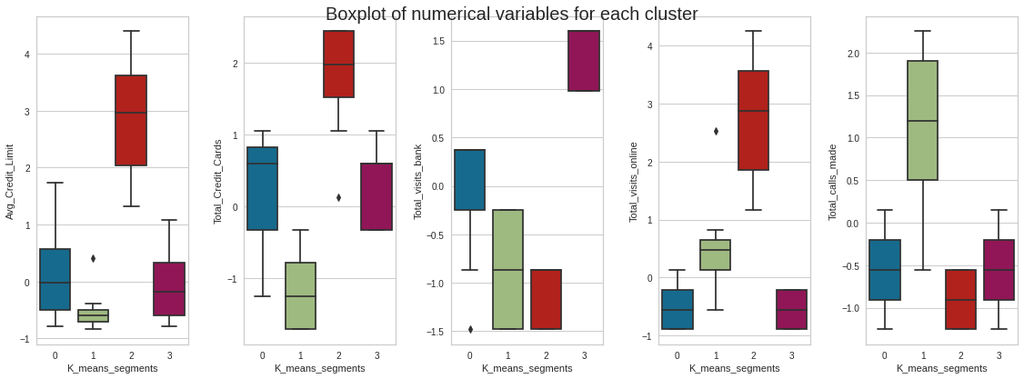

```python
# Figure with Scaled DF
fig, axes = plt.subplots(1, 5,  figsize=(16, 6))
fig.suptitle('Boxplot of numerical variables for each cluster', fontsize=20)
counter = 0
for ii in range(5):
    sns.boxplot(ax=axes[ii],y=subset_scaled_df[all_col[counter]],x=subset_scaled_df['K_means_segments'])
    counter = counter+1

fig.tight_layout(pad=2.0)
```

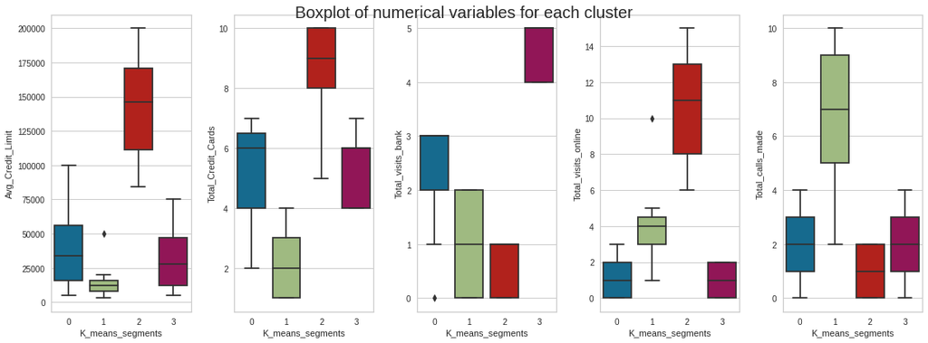

```python
fig, axes = plt.subplots(1, 5,  figsize=(16, 6))
fig.suptitle('Boxplot of numerical variables for each cluster', fontsize=20)
counter = 0
for ii in range(5):
    sns.boxplot(ax=axes[ii],y=ccCustomerDF[all_col[counter]],x=ccCustomerDF['K_means_segments'])
    counter = counter+1

fig.tight_layout(pad=2.0)
```

**Insights of Kmeans Cluster Profile**

Total 4 Clusters

1. Average Credit Limit is range 15K to 53K approx with count of 199 customers.
2. Total credit card in this cluster is 4 to 7 majority group.
3. Bank visit in this cluster in medium around 2 to 3.
4. Online exposure of this cluster is least among the clusters.
5. Number are phone call in range of 2 to 3.

**Cluster -01**

1. Average Credit Limit is under 15K with of 219 customers.
2. Total credit card in this cluster is least 3 or under.
3. Bank visit in this cluster in range of 0 to 2.
4. Online access of this cluster around 3 to 5.
5. Number are phone call in high range of 5 to 10.

**Cluster -02**

1. Average Credit Limit is above 80K with of 49 customers.
2. Total credit card in this cluster is least 8 or above.
3. Bank visit in this cluster in range of 0 to 1.
4. Online visit of this cluster is high range of 8 to 14.
5. Number are phone call in less range of 0 to 2.

**HEIRARCHY Clstering with Different Linkage and Dendogram**

```python
print(ccCustomerDF.columns)
print(subset_scaled_df.columns)
```

```
Index(['Avg_Credit_Limit', 'Total_Credit_Cards', 'Total_visits_bank',
       'Total_visits_online', 'Total_calls_made', 'K_means_segments'],
      dtype='object')
Index(['Avg_Credit_Limit', 'Total_Credit_Cards', 'Total_visits_bank',
       'Total_visits_online', 'Total_calls_made', 'K_means_segments'],
      dtype='object')
```

```python
subset_scaled_df.drop(columns='K_means_segments',inplace=True)
ccCustomerDF.drop(columns='K_means_segments',inplace=True)
```

```python
print(ccCustomerDF.columns)
print(subset_scaled_df.columns)
```

```
Index(['Avg_Credit_Limit', 'Total_Credit_Cards', 'Total_visits_bank',
       'Total_visits_online', 'Total_calls_made'],
      dtype='object')
Index(['Avg_Credit_Limit', 'Total_Credit_Cards', 'Total_visits_bank',
       'Total_visits_online', 'Total_calls_made'],
      dtype='object')
```

*For different distance metrics : Euclidean, chebyshevv, Mahalanobis, cityblock and linkage method computing cophenet correlation*

```python
# cophenet index is a measure of the correlation between the distance of points in feature space and distance on dendrogram
# closer it is to 1, the better is the clustering
distance_metrics = [ 'euclidean','chebyshev','mahalanobis','cityblock']
linkage_methods = ['single', 'complete', 'average', 'weighted']
high_cophenet_corr = 0
high_dm_lm = [0,0]
for dm in distance_metrics:
    for lm in linkage_methods:
        Z = linkage(subset_scaled_df, metric=dm, method=lm)
        c, coph_dists = cophenet(Z , pdist(subset_scaled_df))
        print('Cophent correlation for distance metrics {} and linkahe method {} is {}'.format(dm,lm,c))
        if high_cophenet_corr < c:
            high_cophenet_corr = c
            high_dm_lm[0] = dm
            high_dm_lm[1] = lm
```

```
Cophent correlation for distance metrics euclidean and linkahe method single is 0.7394304750525083
Cophent correlation for distance metrics euclidean and linkahe method complete is 0.8667328091184989
Cophent correlation for distance metrics euclidean and linkahe method average is 0.8978313900952013
Cophent correlation for distance metrics euclidean and linkahe method weighted is 0.8773838357840723
Cophent correlation for distance metrics chebyshev and linkahe method single is 0.737143144216537
Cophent correlation for distance metrics chebyshev and linkahe method complete is 0.8552239895659224
Cophent correlation for distance metrics chebyshev and linkahe method average is 0.8957181498223362
Cophent correlation for distance metrics chebyshev and linkahe method weighted is 0.8863633810565059
Cophent correlation for distance metrics mahalanobis and linkahe method single is 0.7071236045805913
Cophent correlation for distance metrics mahalanobis and linkahe method complete is 0.6756639566633286
Cophent correlation for distance metrics mahalanobis and linkahe method average is 0.8326065559039693
Cophent correlation for distance metrics mahalanobis and linkahe method weighted is 0.6759555556646273
Cophent correlation for distance metrics cityblock and linkahe method single is 0.7253541431732753
Cophent correlation for distance metrics cityblock and linkahe method complete is 0.8745673728293208
Cophent correlation for distance metrics cityblock and linkahe method average is 0.8972350698503513
Cophent correlation for distance metrics cityblock and linkahe method weighted is 0.8816878971897065
```

```python
print('Highest cophenet correlation is {}, which is obtinaed with {} distance metric and {} linkage method'.format(high_cophenet_corr ,high_dm_lm[0],high_dm_lm[1]))
```

```
Highest cophenet correlation is 0.8978313900952013, which is obtinaed with euclidean distance metric and average linkage method
```

**Exploring 'centroid', 'median','ward' linkage method which requires only Euclidean distance metrics**

```python
linkage_methods = ['single', 'complete', 'average','median','ward', 'weighted']
hgh_cophenet_corr = 0
hgh_dm_lm = [0,0]

for lm in linkage_methods:
    Z = linkage(subset_scaled_df, metric='euclidean', method=lm)
    c, coph_dists = cophenet(Z , pdist(subset_scaled_df))
    print('Cophent correlation for distance metrics {} and linkage method {} is {}'.format('euclidean',lm,c))
    if hgh_cophenet_corr < c:
        hgh_cophenet_corr = c
        hgh_dm_lm[0] = 'euclidean'
        hgh_dm_lm[1] = lm
print('='*110)
print('Highest cophenet correlation is {}, which is obtinaed with {} distance metric and {} linkage method'.format(hgh_cophenet_corr ,hgh_dm_lm[0],hgh_dm_lm[1]))
```

```
Cophent correlation for distance metrics euclidean and linkage method single is 0.7394304750525083
Cophent correlation for distance metrics euclidean and linkage method complete is 0.8667328091184989
Cophent correlation for distance metrics euclidean and linkage method average is 0.8978313900952013
Cophent correlation for distance metrics euclidean and linkage method median is 0.8174435946675414
Cophent correlation for distance metrics euclidean and linkage method ward is 0.7399284005362226
Cophent correlation for distance metrics euclidean and linkage method weighted is 0.8773838357840723
==============================================================================================================
Highest cophenet correlation is 0.8978313900952013, which is obtinaed with euclidean distance metric and average linkage method
```

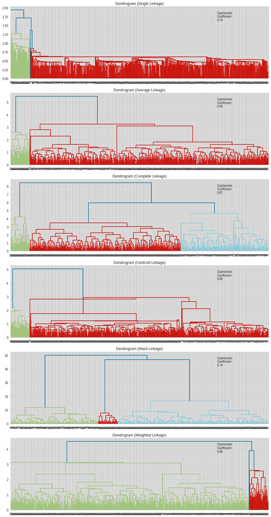

```python
# List of all linkage methods to check
methods = ['single',
           'average',
           'complete',
           'centroid',
           'ward',
          'weighted']

# Calculate the pairwise distance form the dataset to be used in the cophenetic correlation calculation
#pw_distance = pdist(credit_scaled)

# Create lists to save results of coph calculation
compare_cols = ['Linkage', 'Cophenetic Coefficient']
compare = []

# Create a subplot image
fig, axs = plt.subplots(len(methods), 1, figsize=(15, 30))

# Enumerate through the list of all methods above
# Get linkage, plot dendrogram, calculate cophenetic coefficient
for i, method in enumerate(methods):

    Z = linkage(subset_scaled_df, metric='euclidean', method=method)

    dendrogram(Z, ax=axs[i]);
    axs[i].set_title(f'Dendrogram ({method.capitalize()} Linkage)')
    coph_corr, coph_dist = cophenet(Z, pdist(subset_scaled_df))
    axs[i].annotate(f'Cophenetic\nCoefficient\n{coph_corr:0.2f}',
                    (0.80, 0.80),
                    xycoords='axes fraction')
    compare.append([method, coph_corr])
```

Dendrogram with ward linkage method shows distinct and separate cluster

```python
# Create and print dataframe to compare Cophenetic Coefficient for each linkage
df_cc = pd.DataFrame(compare, columns=compare_cols)
df_cc
```

|  | Linkage | Cophenetic Coefficient |
| --- | --- | --- |
| 0 | single | 0.739430 |
| 1 | average | 0.897831 |
| 2 | complete | 0.866733 |
| 3 | centroid | 0.894840 |
| 4 | ward | 0.739928 |
| 5 | weighted | 0.877384 |

*Insights*

As high cophenetic coefficient is best fit for clusters, linkage type average with cophentic coefficient is choice to select.

Observations

1. Out of all the dendrogram we saw, it is clear that dendrogram with ward linkage method gave us separate and distinct clusters
2. 3 cluster would be appropriate number of cluster from dendrogram with ward linkage method

```python
HCmodel = AgglomerativeClustering(n_clusters=3,affinity='euclidean', linkage='ward')
HCmodel.fit(subset_scaled_df)
subset_scaled_df['HC_Clusters'] = HCmodel.labels_
```

```python
HCmodel.labels_
```

```
array([0, 1, 0, 0, 1, 2, 1, 1, 1, 1, 1, 1, 1, 1, 1, 1, 1, 1, 1, 1, 1, 1,
       1, 1, 1, 1, 1, 1, 1, 1, 1, 1, 1, 1, 1, 1, 1, 1, 1, 1, 1, 1, 1, 1,
       1, 1, 1, 1, 1, 1, 1, 1, 1, 1, 1, 1, 1, 1, 1, 1, 1, 1, 1, 1, 1, 1,
       1, 1, 1, 1, 1, 1, 1, 1, 1, 1, 1, 1, 1, 1, 1, 1, 1, 1, 1, 1, 1, 1,
       1, 1, 1, 1, 1, 1, 1, 1, 1, 1, 1, 1, 1, 1, 1, 1, 1, 1, 1, 1, 1, 1,
       1, 1, 1, 1, 1, 1, 1, 1, 1, 1, 1, 1, 1, 1, 1, 1, 1, 1, 1, 1, 1, 1,
       1, 1, 1, 1, 1, 1, 1, 1, 1, 1, 1, 1, 1, 1, 1, 1, 1, 1, 1, 1, 1, 1,
       1, 1, 1, 1, 1, 1, 1, 1, 1, 1, 1, 1, 1, 1, 1, 1, 1, 1, 1, 1, 1, 1,
       1, 1, 1, 1, 1, 1, 1, 1, 1, 1, 1, 1, 1, 1, 1, 1, 1, 1, 1, 1, 1, 1,
       1, 1, 1, 1, 1, 1, 1, 1, 1, 1, 1, 1, 1, 1, 1, 1, 1, 1, 1, 1, 1, 1,
       1, 1, 1, 1, 1, 0, 0, 0, 0, 0, 0, 0, 0, 0, 0, 0, 0, 0, 0, 0, 0, 0,
       0, 0, 0, 0, 0, 0, 0, 0, 0, 0, 0, 0, 0, 0, 0, 0, 0, 0, 0, 0, 0, 0,
       0, 0, 0, 0, 0, 0, 0, 0, 0, 0, 0, 0, 0, 0, 0, 0, 0, 0, 0, 0, 0, 1,
       0, 0, 0, 0, 0, 0, 0, 0, 0, 0, 0, 0, 0, 0, 0, 0, 0, 0, 0, 0, 0, 0,
       0, 0, 1, 0, 0, 0, 0, 0, 0, 0, 0, 0, 0, 0, 0, 0, 0, 0, 0, 0, 0, 0,
       0, 0, 0, 0, 0, 0, 0, 0, 0, 0, 0, 0, 0, 0, 0, 0, 0, 0, 0, 0, 0, 0,
       0, 0, 0, 0, 0, 0, 0, 0, 0, 0, 0, 0, 0, 0, 0, 0, 0, 0, 0, 0, 0, 0,
       0, 0, 0, 0, 0, 0, 0, 0, 0, 0, 0, 0, 0, 0, 0, 0, 0, 0, 0, 0, 0, 0,
       0, 0, 0, 0, 0, 0, 0, 0, 0, 0, 0, 0, 0, 0, 0, 0, 0, 0, 0, 0, 0, 0,
       0, 0, 0, 0, 0, 0, 0, 0, 0, 0, 0, 0, 0, 0, 0, 0, 0, 0, 0, 0, 0, 0,
       0, 0, 0, 0, 0, 0, 0, 0, 0, 0, 0, 0, 0, 0, 0, 0, 0, 0, 0, 0, 0, 0,
       0, 0, 0, 0, 0, 0, 0, 0, 0, 0, 0, 0, 0, 0, 0, 0, 0, 0, 0, 0, 0, 0,
       0, 0, 0, 0, 0, 0, 0, 0, 0, 0, 0, 0, 0, 0, 0, 0, 0, 0, 0, 0, 0, 0,
       0, 0, 0, 0, 0, 0, 0, 0, 0, 0, 0, 0, 0, 0, 0, 0, 0, 0, 0, 0, 0, 0,
       0, 0, 0, 0, 0, 0, 0, 0, 0, 0, 0, 0, 0, 0, 0, 0, 0, 0, 0, 0, 0, 0,
       0, 0, 0, 0, 0, 0, 0, 0, 0, 0, 0, 0, 0, 0, 0, 0, 0, 0, 0, 0, 0, 0,
       0, 0, 0, 0, 0, 0, 0, 0, 0, 0, 0, 0, 0, 0, 0, 0, 0, 0, 0, 0, 0, 0,
       0, 0, 0, 0, 0, 0, 0, 0, 0, 0, 0, 0, 0, 2, 2, 2, 2, 2, 2, 2, 2, 2,
       2, 2, 2, 2, 2, 2, 2, 2, 2, 2, 2, 2, 2, 2, 2, 2, 2, 2, 2, 2, 2, 2,
       2, 2, 2, 2, 2, 2, 2, 2, 2, 2, 2, 2, 2, 2, 2, 2, 2])
```

```python
ccCustomerDF['HC_Clusters'] = HCmodel.labels_
```

```python
heirarchy_cluster_profile = ccCustomerDF.groupby('HC_Clusters').mean()
```

```python
heirarchy_cluster_profile['count_in_each_segments'] = ccCustomerDF.groupby('HC_Clusters')['Total_calls_made'].count().values
```

```python
# lets display cluster profile
heirarchy_cluster_profile.style.highlight_max(color = 'black', axis = 0)
```

| HC_Clusters | Avg_Credit_Limit | Total_Credit_Cards | Total_visits_bank | Total_visits_online | Total_calls_made | count_in_each_segments |
| --- | --- | --- | --- | --- | --- | --- |
| 0 | 33879.895561 | 5.524804 | 3.485640 | 0.984334 | 2.000000 | 383 |
| 1 | 12156.950673 | 2.417040 | 0.941704 | 3.560538 | 6.838565 | 223 |
| 2 | 141877.551020 | 8.795918 | 0.612245 | 10.877551 | 1.040816 | 49 |

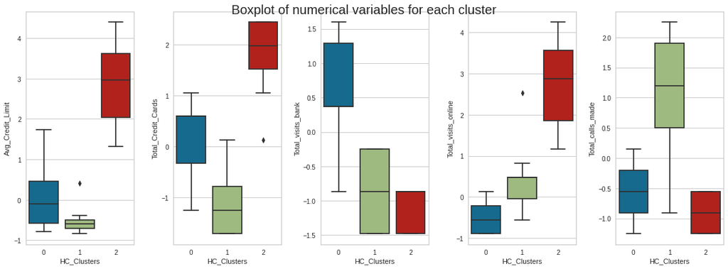

```python
# For subset_scaled_df
fig, axes = plt.subplots(1, 5,  figsize=(16, 6))
fig.suptitle('Boxplot of numerical variables for each cluster', fontsize=20)
counter = 0
for ii in range(5):
    sns.boxplot(ax=axes[ii],y=subset_scaled_df[all_col[counter]],x=subset_scaled_df['HC_Clusters'])
    counter = counter+1

fig.tight_layout(pad=2.0)
```

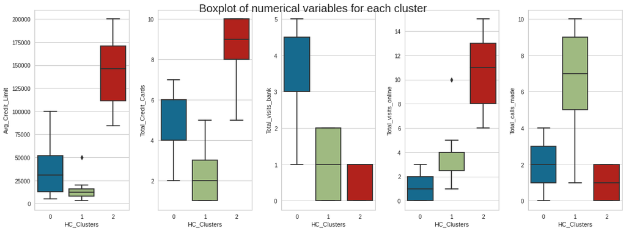

```python
# For orginaal data
fig, axes = plt.subplots(1, 5,  figsize=(16, 6))
fig.suptitle('Boxplot of numerical variables for each cluster', fontsize=20)
counter = 0
for ii in range(5):
    sns.boxplot(ax=axes[ii],y=ccCustomerDF[all_col[counter]],x=ccCustomerDF['HC_Clusters'])
    counter = counter+1

fig.tight_layout(pad=2.0)
```

**Insights on Cluster - Heirarchy Clustering with Linkage**

**Cluster- 0**

1. 75 percentile Average Credit Limit is in range of 12000 to 52000.
2. Total credit card customer hold in the cluster is in range of 4 to 6. Even few outlier of at 7 and 2 to 3.
3. Bank visit in this cluster looks high than other clusters.
4. Online exposure of this cluster looks minimal.
5. Number are phone call in medium range.

**Comparison of Kmeans and Heirarchy Cluster Profiling**

```python
# Heirarchy Clusters
heirarchy_cluster_profile.style.highlight_max(color = 'red', axis = 0)
```

| HC_Clusters | Avg_Credit_Limit | Total_Credit_Cards | Total_visits_bank | Total_visits_online | Total_calls_made | count_in_each_segments |
| --- | --- | --- | --- | --- | --- | --- |
| 0 | 33879.895561 | 5.524804 | 3.485640 | 0.984334 | 2.000000 | 383 |
| 1 | 12156.950673 | 2.417040 | 0.941704 | 3.560538 | 6.838565 | 223 |
| 2 | 141877.551020 | 8.795918 | 0.612245 | 10.877551 | 1.040816 | 49 |

```python
# Kmeans Cluster profile
kmeans_cluster_profile.style.highlight_max(color = 'red', axis = 0)
```

| K_means_segments | Avg_Credit_Limit | Total_Credit_Cards | Total_visits_bank | Total_visits_online | Total_calls_made | count_in_each_segments |
| --- | --- | --- | --- | --- | --- | --- |
| 0 | 35904.522613 | 5.522613 | 2.477387 | 0.969849 | 2.075377 | 199 |
| 1 | 12173.515982 | 2.388128 | 0.931507 | 3.589041 | 6.904110 | 219 |
| 2 | 141877.551020 | 8.795918 | 0.612245 | 10.877551 | 1.040816 | 49 |
| 3 | 31255.319149 | 5.494681 | 4.510638 | 1.021277 | 1.946809 | 188 |

**Comparison of Cluster Profile Kmeans vs Heirarchy**

Since Kmeans profile clusters give more granularity how to improve service to custmers, we can go with Kmeans Clustering

**Recommendation for Business and Insights**

> Approching New Customers
> 1. From data it revealed when credit limit increases, the number of visit to bank calls is reduced drastically. visit to bank cost cutomer more money and unhappy.
> 2. It is advisable of proviing high credit limit and increase the number of credit card.
> 3. Improving online service better, helps customers to resolve quicker and it can save money to the bank.

> Overselling Existing customers
1. Engage the customers to take new additional cards.
2. Increase the Average credit limit for the credit card holders.
3. concentrate on cluster - 0 of kmeans and encourage in using online service for the customers.
4. Improve customer experience on calls made to the bank.
5. Improve AI to have auto issue resolver via call. There by cluster -1 of kmean will have better service.